# Homework #5 - Solution

## 17 points total for the homework

### Problem 1

## 1 pt

### A. Read in the data, saving it to a variable called `astrag`. Hint: be sure to specify the separator character in the data, which is a tab (represented in R as `\t`).

```r
astrag <- read.table("http://hompal-stats.wabarr.com/datasets/barr_astrag_2014.txt", sep="\t", header=TRUE)
```

## 2 pts

### B. Make a scatterplot with the natural logarithm of measurement `B` on the x-axis and the natural logarithm of measurement `DistRad` on the y-axis.

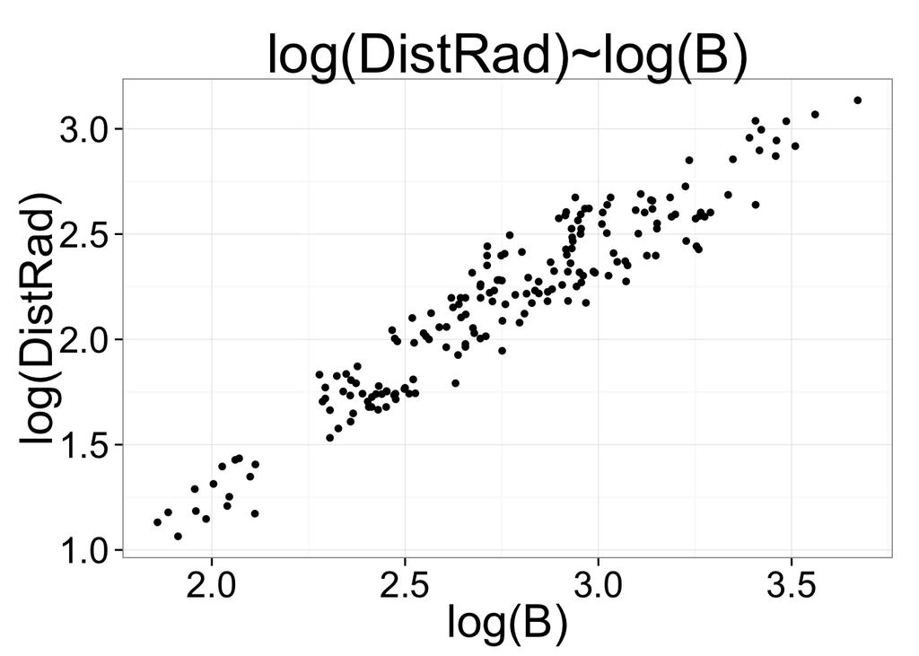

```r
library(ggplot2)
scatter <- ggplot() +
              geom_point(aes(x=log(B), y=log(DistRad)), data=astrag) +
              labs(title="log(DistRad)~log(B)") +
              theme_bw(25)
scatter
```

## 2 pts

### C. Calculate the ordinary least-squares (OLS) regression for the log of DistRad as a function of the log of B, and print a `summary()` of this data.

```r
OLS_model <- lm(log(DistRad)~log(B), data=astrag)
summary(OLS_model)
```

```
##
## Call:
## lm(formula = log(DistRad) ~ log(B), data = astrag)
##
## Residuals:
##      Min       1Q   Median       3Q      Max
## -0.30157 -0.10421 -0.00748  0.09753  0.31963
##
## Coefficients:
##             Estimate Std. Error t value Pr(>|t|)
## (Intercept) -0.88445    0.07236  -12.22   <2e-16 ***
## log(B)       1.10855    0.02600   42.63   <2e-16 ***
## ---
## Signif. codes:  0 '***' 0.001 '**' 0.01 '*' 0.05 '.' 0.1 ' ' 1
##
## Residual standard error: 0.1349 on 185 degrees of freedom
## Multiple R-squared:  0.9076, Adjusted R-squared:  0.9071
## F-statistic:  1817 on 1 and 185 DF,  p-value: < 2.2e-16
```

## 3 pts

### D. Calculate the reduced major axis regression (RMA) for the same variables. **Note** the `lmodel2` package uses “RMA”" to refer to “Ranged Major Axis”, which is different. You want what `lmodel2` calls Standardized Major Axis (SMA), which is equivalent to what we call reduced major axis (RMA) in our literature.

```r
library(lmodel2)
RMA_model <- lmodel2(log(DistRad)~log(B), data=astrag)
```

```
## RMA was not requested: it will not be computed.
##
## No permutation test will be performed
```

```r
RMA_model
```

```
##
## Model II regression
##
## Call: lmodel2(formula = log(DistRad) ~ log(B), data = astrag)
##
## n = 187   r = 0.9526853   r-square = 0.9076092
## Parametric P-values:   2-tailed = 1.286004e-97    1-tailed = 6.430018e-98
## Angle between the two OLS regression lines = 2.744561 degrees
##
## Regression results
##   Method  Intercept    Slope Angle (degrees) P-perm (1-tailed)
## 1    OLS -0.8844535 1.108552        47.94708                NA
## 2     MA -1.0602519 1.172325        49.53564                NA
## 3    SMA -1.0362204 1.163608        49.32436                NA
##
## Confidence intervals
##   Method 2.5%-Intercept 97.5%-Intercept 2.5%-Slope 97.5%-Slope
## 1    OLS      -1.027206      -0.7417007   1.057250    1.159854
## 2     MA      -1.213964      -0.9145619   1.119474    1.228087
## 3    SMA      -1.180755      -0.8979175   1.113436    1.216040
##
## Eigenvalues: 0.3329658 0.007876679
##
## H statistic used for computing C.I. of MA: 0.0005221113
```

## 1 pts

### E. Is the OLS slope greater or less than the the RMA slope?

The OLS slope (1.108552) is less than the RMA slope (1.163608).

## 3 pts

### F. Add both the OLS and the RMA regression lines to the plot created in 1B. Make sure the two lines have different colors and/or line types, and that they are labeled so I know which is which.

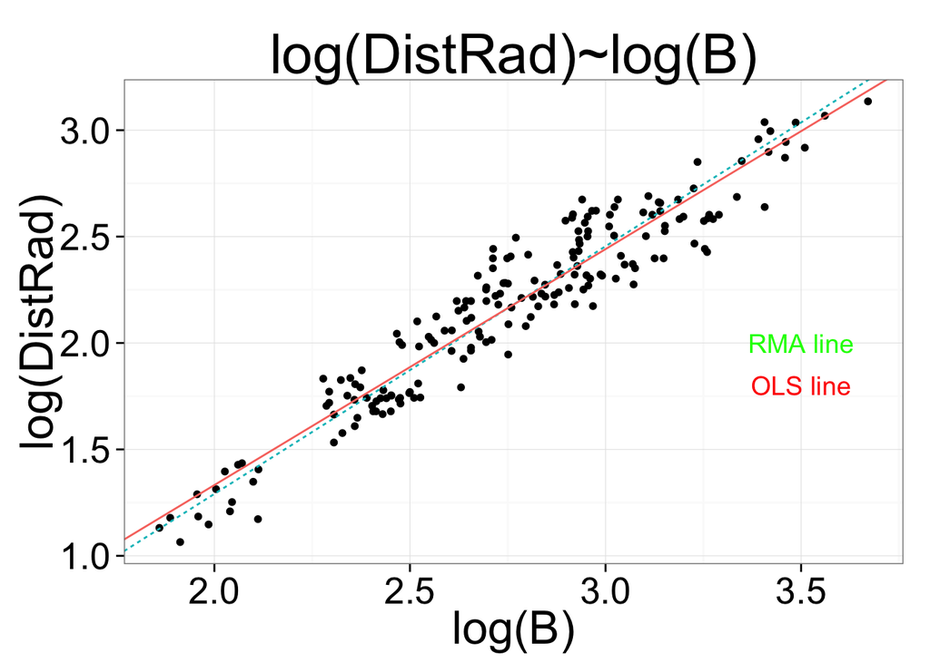

```r
reg_lines <- data.frame(slopes = c(RMA_model$regression.results[3,3],coef(OLS_model)[2]),
                        intercepts = c(RMA_model$regression.results[3,2], coef(OLS_model)[1]), method=c("RMA","OLS")
                        )
scatter +
  geom_abline(aes(slope=slopes, intercept=intercepts, linetype=method, color=method), data=reg_lines) +
  annotate(geom = "text", x = 3.5, y=c(2,1.8), label=c("RMA line", "OLS line"), color=c("green", "red"))
```

## 3 pts

### G. use the `plot()` function to plot regression diagnostic plots for the OLS regression. Do the assumptions of linear regression appear to be met? Explain your answer.

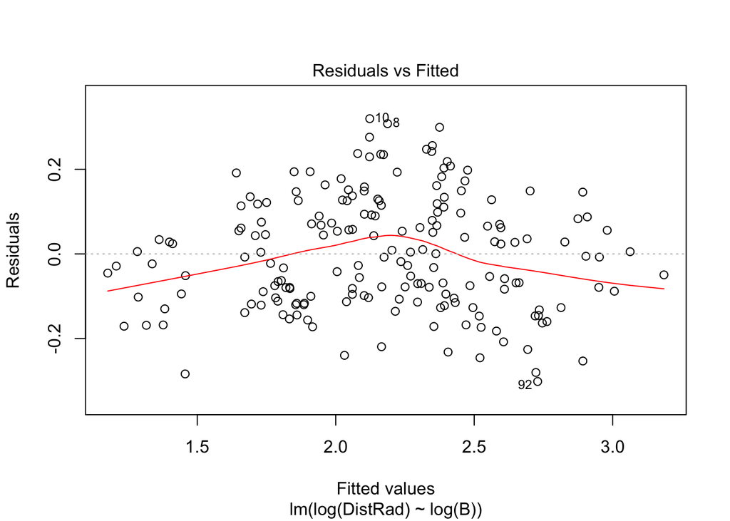

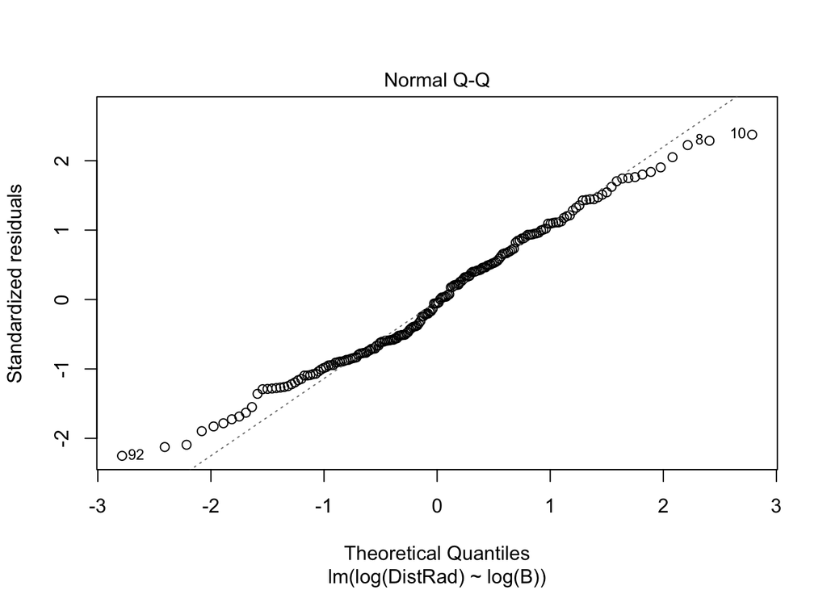

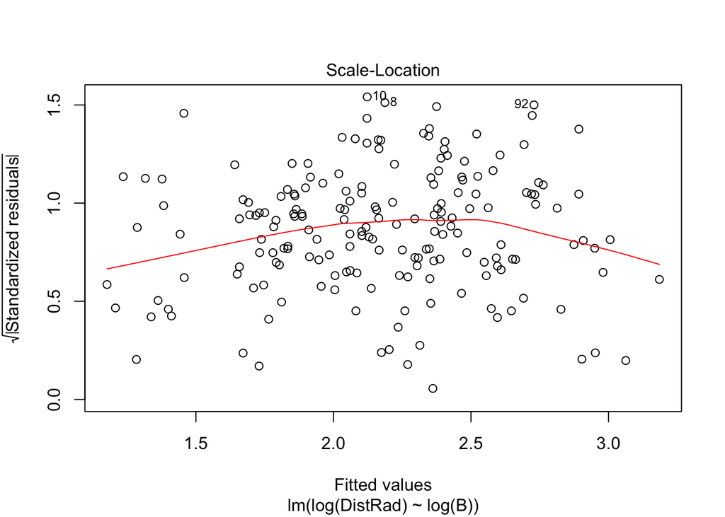

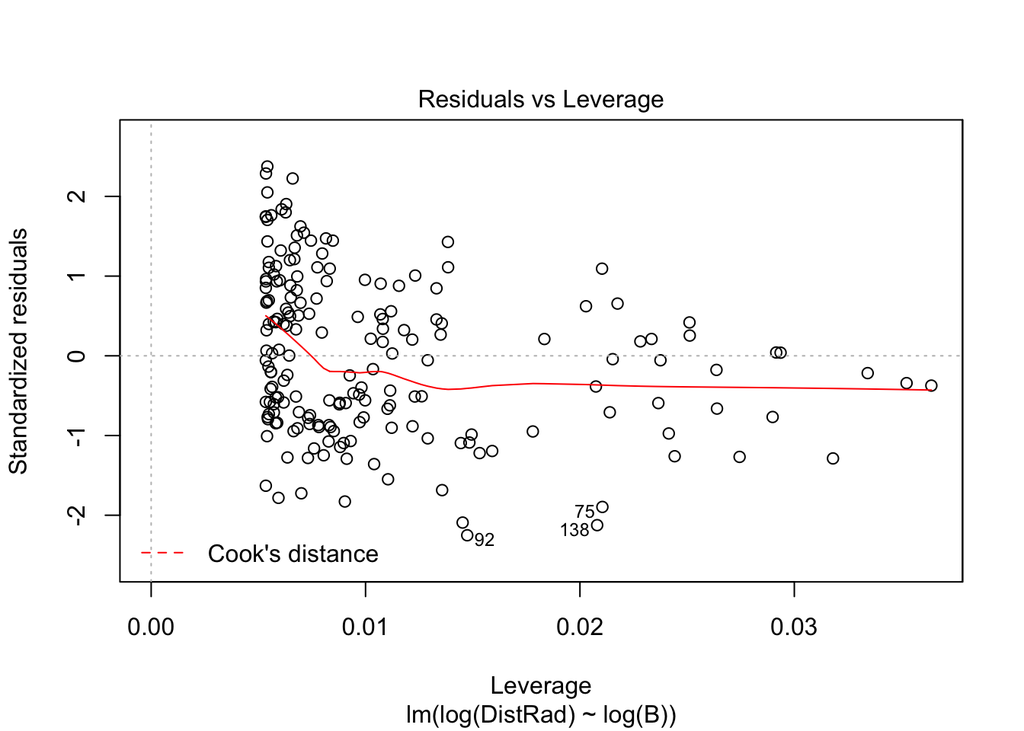

```r
plot(OLS_model)
```

There is evidence that the residuals are not normally distributed.

## 2 pts

### H. Extract the residuals from the OLS regression, and make a histogram of them, with the appropriate labels and title for the plot.

```
## stat_bin: binwidth defaulted to range/30. Use 'binwidth = x' to adjust this.
```

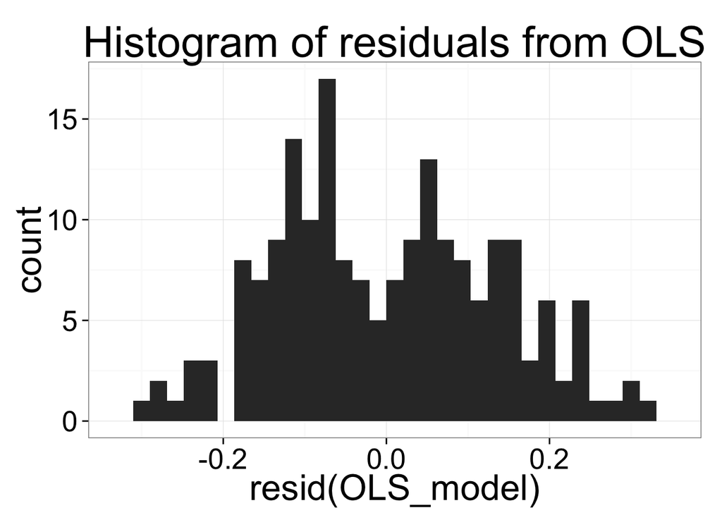

```r
qplot(resid(OLS_model), main="Histogram of residuals from OLS") + theme_bw(25)
```